# Bus Ride Cleanliness Observations

## What’s going on with this data?

[figure not shown]

## The First Graph

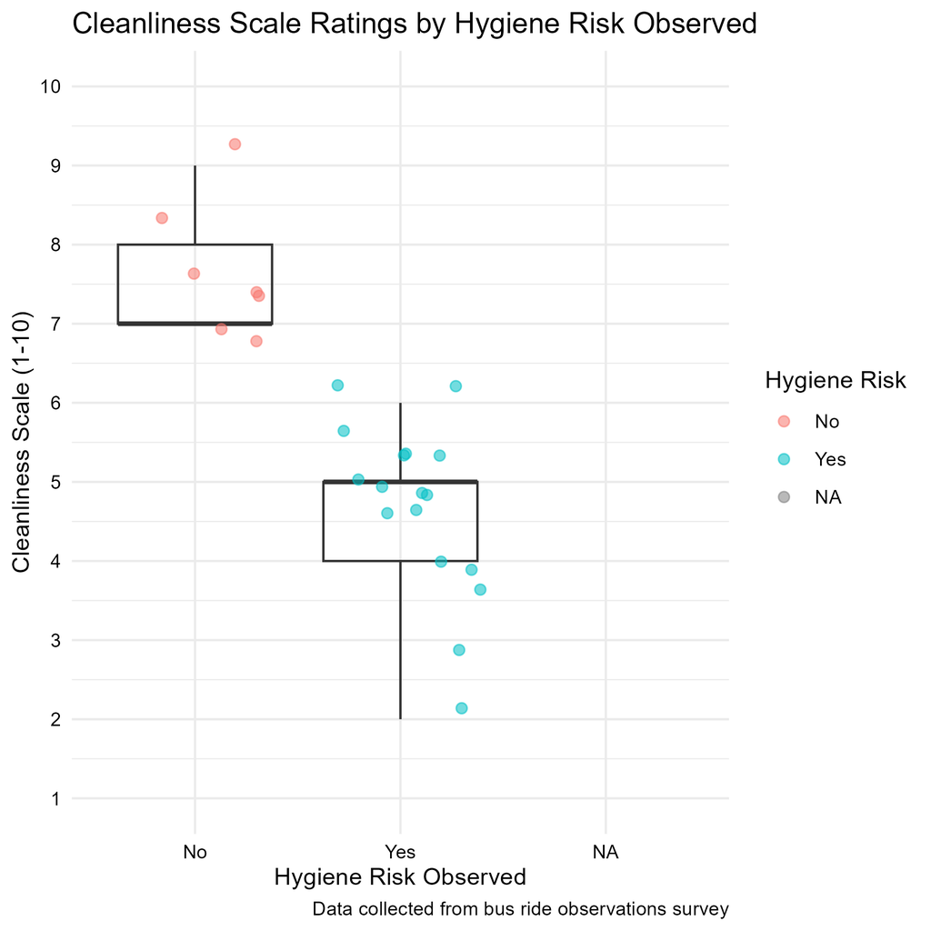

My first graph

The first graph compares the cleanliness scale ratings from 1-10 and the observed hygiene risk during the bus rides. From this, as the hygiene risk is observed, the cleanliness scale tends to be lower where the mean rating is approximately 4.71. Whereas, as the hygiene risk is not observed, the cleanliness scale tends to be higher where the mean rating is approximately 7.57. Since NA was an option in my survey, there was no response data for NA. Therefore, it remains blank until there is a response.

## The Second Graph

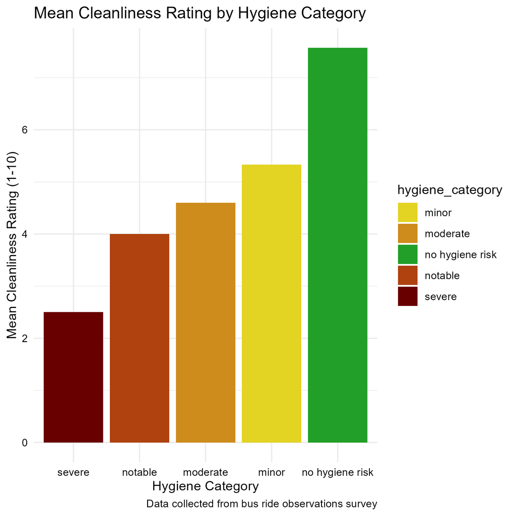

My second graph

The second graph shows the hygiene category’s mean cleanliness rating (1-10). As the severity of the hygiene category increases, the average cleanliness rating tends to decrease. Therefore, the mean cleanliness rating for a hygiene category for minor is approximately 5.33, moderate is approximately 4.6, notable is approximately 4, and severe is approximately 2.5 rating.

There were no records for the very severe category during the observation survey. More information regarding the lack of hygiene risk is in my project report.

## The Thrid Graph

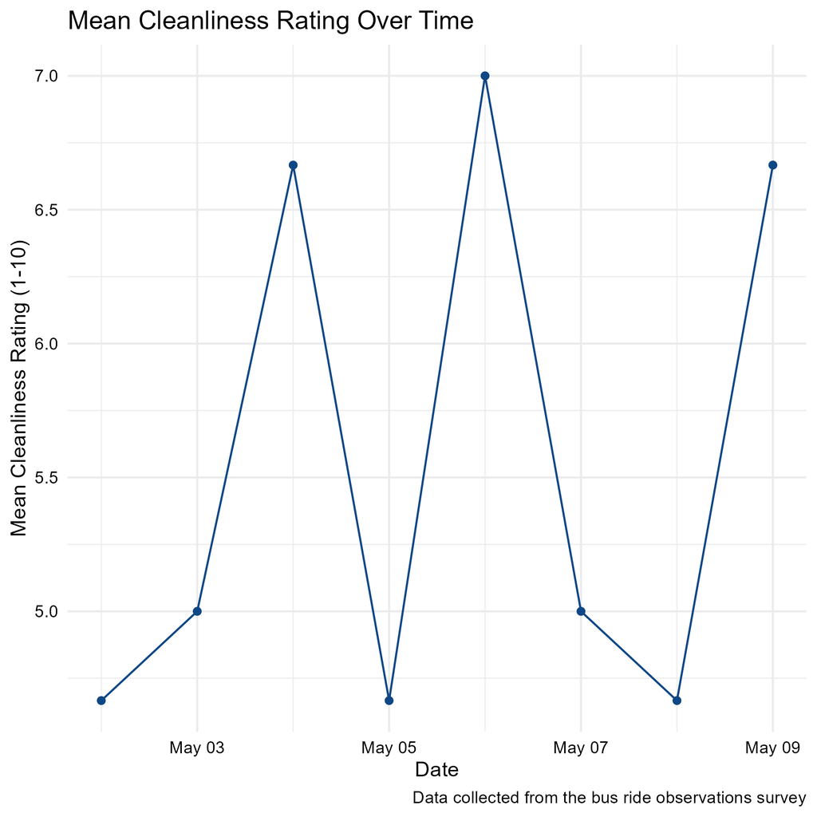

My third graph

```
## # A tibble: 45 × 2
##    Timestamp           mean_cleanliness
##    <chr>                          <dbl>
##  1 02/05/2025 10:33:52                5
##  2 02/05/2025 11:35:07                5
##  3 02/05/2025 14:45:52                4
##  4 03/05/2025 10:36:57                5
##  5 03/05/2025 12:24:42                5
##  6 03/05/2025 15:20:32                5
##  7 04/05/2025 10:39:10                7
##  8 04/05/2025 11:40:02                7
##  9 04/05/2025 14:21:23                6
## 10 05/05/2025 08:34:11                3
## # ℹ 35 more rows
```